# Overinformativeness BDA

# Set up environment

```r
library(gridExtra)
```

# Analyze color-size results

## Parameters

Read parameter data from BDA and compute MAPs and HDIs.

| parameter | mode | md_lo | md_hi |
| --- | --- | --- | --- |
| alpha | 31.3650568862 | 30.689 | 34.513 |
| colorCost | 0.0281194559 | 0.000 | 0.447 |
| colorTyp | 0.8755662898 | 0.852 | 0.916 |
| costDiff | -0.0004264696 | -0.230 | 0.462 |
| sizeCost | 0.0254845847 | 0.000 | 0.263 |
| sizeTyp | 0.7878756748 | 0.763 | 0.808 |
| typDiff | 0.0943761657 | 0.085 | 0.119 |
| typWeight | 0.9988445880 | 1.000 | 1.000 |

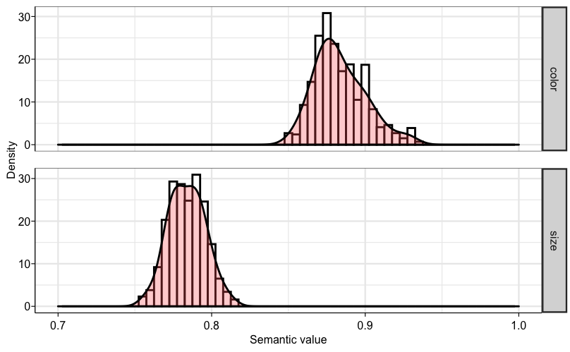

Clearly see that color semantic vaue is much greater than size (basically non-overlapping posteriors).

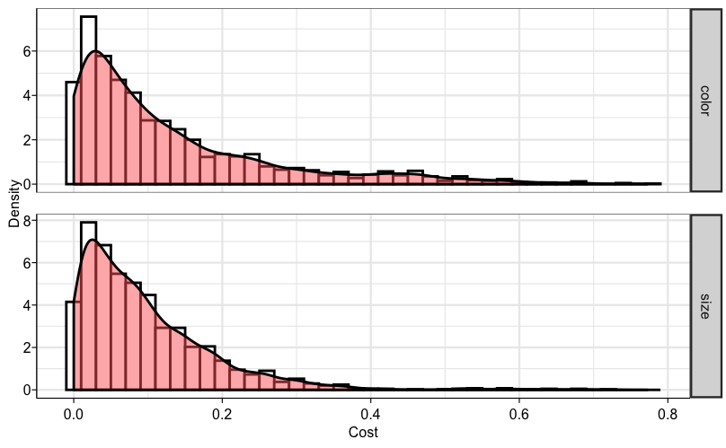

Stick together semantic value and cost plots for paper.

```r
tiff(file="../writing/pics/fig6.tiff",units="in",width=5.5,height=2.7,res=600)
grid.arrange(typParamPosteriors,costParamPosteriors,nrow=1)
dev.off()
```

Inferred difference in color and size semantic value always above zero:

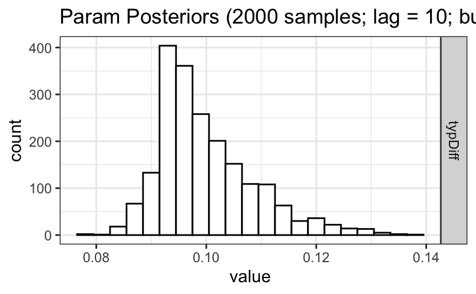

Inferred difference in color and size cost around zero:

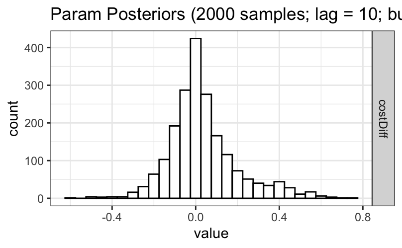

## Predictives

Load empirical data and get into right format.

```r
empirical = emp %>%
  mutate(CondLength = nchar(as.character(Condition))) %>%
  mutate(SufficientDimension =
           case_when( CondLength == 7 ~ "color",
                      CondLength == 6 ~ "size",
                      TRUE ~ "error"),
         NumDistractors = as.numeric(as.character(str_sub(Condition,CondLength-1,CondLength-1))),
         NumSameDistractors = as.numeric(as.character(str_sub(Condition,CondLength,CondLength))),
         NumDiffDistractors = NumDistractors-NumSameDistractors,
         Variation = NumDiffDistractors/NumDistractors) %>%
  select(SufficientDimension,NumDistractors,Variation,Utterance) %>%
  mutate(Color = Utterance == "color",
         Size = Utterance == "size",
         Size_Color = Utterance == "size_color") %>%
  group_by(SufficientDimension,NumDistractors,Variation) %>%
  summarize(ProbColor = mean(Color),ProbSize = mean(Size),ProbSize_Color = mean(Size_Color),CILowC=ci.low(Color),CIHighC=ci.high(Color),CILowS=ci.low(Size),CIHighS=ci.high(Size),CILowSC=ci.low(Size_Color),CIHighSC=ci.high(Size_Color)) %>%
  ungroup() %>%
  mutate(YMinSize=ProbSize-CILowS,YMaxSize=ProbSize+CIHighS,YMinColor=ProbColor-CILowC,YMaxColor=ProbColor+CIHighC,YMinSize_Color=ProbSize_Color-CILowSC,YMaxSize_Color=ProbSize_Color+CIHighSC)
```

```
Error in summarize(., ProbColor = mean(Color), ProbSize = mean(Size),  :
  argument "by" is missing, with no default
```

Load predictives and get into right format.

```r
pred = read.csv("../models/bdaOutput/colorSize_predictives.csv",quote="")
```

Bind empirical and predictives.

```r
d = rbind(empirical,predictives)
```

```
Error in rbind(deparse.level, ...) :
  numbers of columns of arguments do not match
```

Make Fig 6 plot analogous to Fig 4.

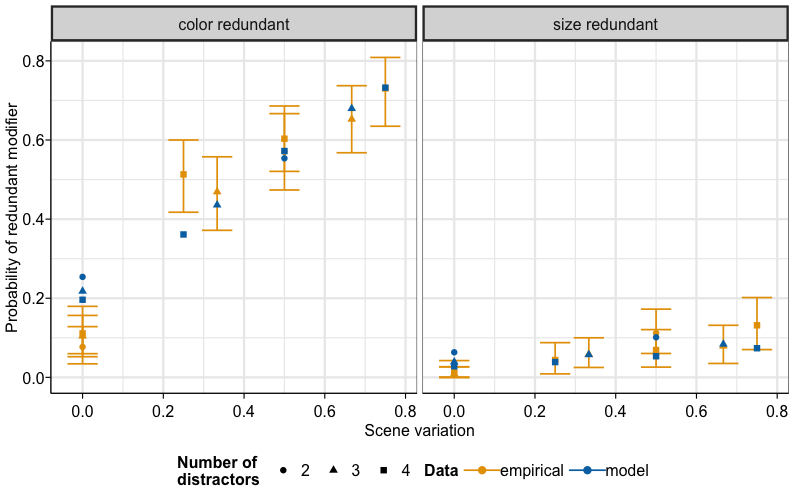

Make Fig 7 a scatterplot of all data points fit in Exp 1.

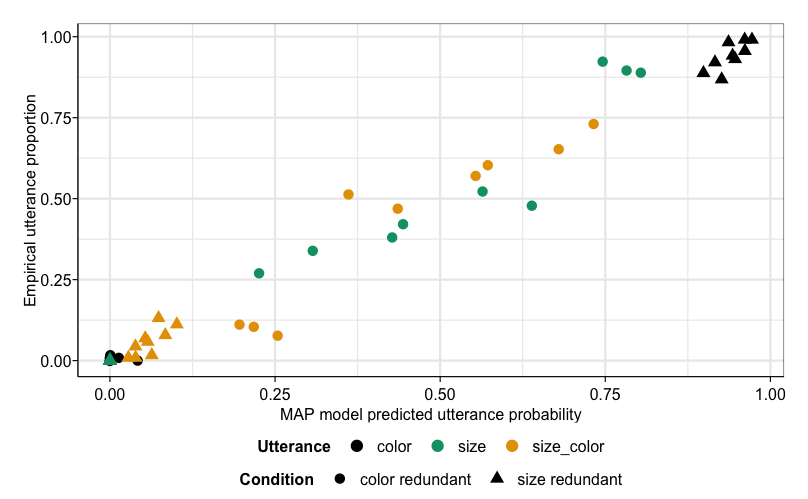

# Analyze color typicality results

## Parameters

Read parameter data from BDA with **empirical costs** and **empirical semantics** and compute MAPs and HDIs.

| parameter | mode | md_lo | md_hi |
| --- | --- | --- | --- |
| colorCost | -0.001155412 | 0.000 | 0.000 |
| colorTyp | 0.857317977 | 0.824 | 0.885 |
| fixedVsEmpirical | 0.686702757 | 0.636 | 0.765 |
| infWeight | 13.741197193 | 11.577 | 14.368 |
| sizeCost | -0.001155412 | 0.000 | 0.000 |
| sizeTyp | -0.001155412 | 0.000 | 0.000 |
| typeCost | -0.001155412 | 0.000 | 0.000 |
| typeTyp | 0.997660605 | 0.970 | 1.000 |
| typWeight | 1.335239166 | 1.186 | 1.745 |

Plot posteriors over parameters.

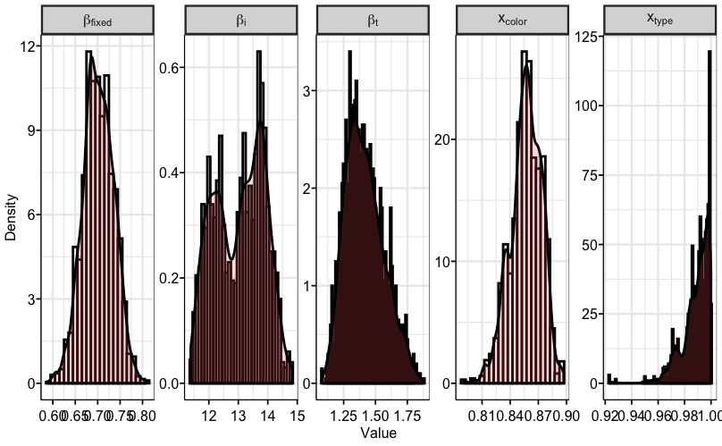

```r
typParamPosteriors
```

## Predictives

Load empirical data and get into right format.

```r
empirical = read.csv("../models/bdaInput/typicality/bda_data.csv") %>%
  mutate(target_item = paste(t_color, t_item, sep = "_")) %>%
  mutate(utterance = case_when (
    as.character(response) == as.character(t_color) ~ "color",
    as.character(response) == as.character(t_item) ~ "item",
    as.character(response) == as.character(target_item) ~ "color_item",
    TRUE ~ "other"
  )) %>%
  select(condition,target_item,utterance) %>%
  group_by(condition,target_item) %>%
  count(utterance) %>%
  mutate(EmpiricalProp = n / sum(n)) %>%
  ungroup() %>%
  select(-n)
```

Load predictives and get into right format.

```r
predictives = pred %>%
  mutate(probability = exp(logProbability),
         target_item=paste(target_color,"_",target_type,sep="")) %>%
  # filter(as.character(Utterance) %in% c(as.character(TargetColor),as.character(TargetType),Target)) %>%
  mutate_at(vars(utterance,target_color,target_type),funs(as.character(.))) %>%
  mutate(utterance = case_when(
    utterance == target_color ~ "color",
    utterance == target_type ~ "item",
    utterance == target_item ~ "color_item",
    TRUE ~ "other"
    )) %>%
  filter(utterance != 'other') %>%
  # filter(Utterance == TargetColor | Utterance == TargetType | Utterance == Target) %>%
  select(condition,target_item,utterance,probability) %>%
  group_by(condition,target_item,utterance) %>%
  summarise(ModelProb=mean(probability),CILow=ci.low(probability),CIHigh=ci.high(probability)) %>%
  ungroup() %>%
  mutate(ModelYMin=ModelProb-CILow,ModelYMax=ModelProb+CIHigh) %>%
  select(-CILow,-CIHigh)
```

[output not shown]

Load typicalities.

Plot model predictions

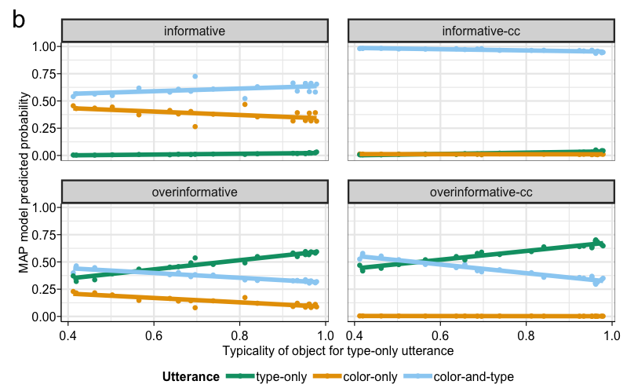

Get empirical plot analogous to model plot, then stick the two together

```r
tiff(file="../writing/pics/fig13.tiff",units="in",width=3.6,height=6.5,res=600)
grid.arrange(empiricalplot,modelplot,nrow=2)
dev.off()
```

Bind empirical and predictives and plot correlation

```r
d = left_join(predictives,empirical,by=c("condition","target_item","utterance")) %>%
  replace_na(list(EmpiricalProp = 0))
cor(d$ModelProb,d$EmpiricalProp)

ggplot(d, aes(x=ModelProb,y=EmpiricalProp,color=condition)) +
  geom_errorbar(aes(ymin=ModelYMin,ymax=ModelYMax)) +
  # geom_errorbarh(aes(xmin=ModelYMin,xmax=ModelYMax)) +
  geom_point() +
  xlab("Model predicted probability") +
  ylab("Empirical utterance proportion") +
  # facet_wrap(~condition) +
  theme_bw() +
  geom_abline(intercept = 0, slope = 1, linetype = "dotted") +
  guides(color=guide_legend(title="utterance")) +
  theme(aspect.ratio = 1)
ggsave("../writing/pics/exp3-empirical-predictives.pdf",height=4,width=11)
```

[output not shown]

## Model comparison

Load BF results

```r
AIS.samples <- read_csv('../models/BFOutput/BF_typicality.txt') %>%
  group_by(modelVersion, costs, semantics) %>%
  summarize(m = mean(margLikelihood))

# fixedplusempirical vs. empirical
AIS.samples %>% spread(semantics, m) %>%
  mutate(BF1 = exp(fixedplusempirical - empirical),
         BF2 = format( exp(fixedplusempirical - fixed),
                       scientific = TRUE, digits = 3))

# no cost vs. cost
AIS.samples %>% filter(semantics == 'fixedplusempirical') %>%
  spread(costs, m) %>%
  mutate(noneVsFixedBF = exp(none - fixed)) %>%
  mutate(noneVsEmpBF = exp(none - empirical)) %>%
  select(noneVsFixedBF, noneVsEmpBF)
```

[output not shown]

# Analyze nominal choice results

## Parameters

Read parameter data from BDA and compute MAPs and HDIs for cost-model.

| parameter | mode | md_lo | md_hi |
| --- | --- | --- | --- |
| empiricalVsTruthConditional | 0.003835642 | 0.000 | 0.030 |
| freqCostWeight | 0.021263577 | 0.000 | 0.185 |
| infWeight | 19.797566090 | 17.707 | 20.000 |
| lengthCostWeight | 2.694032207 | 2.418 | 2.992 |
| typWeight | 0.573243255 | 0.525 | 0.666 |

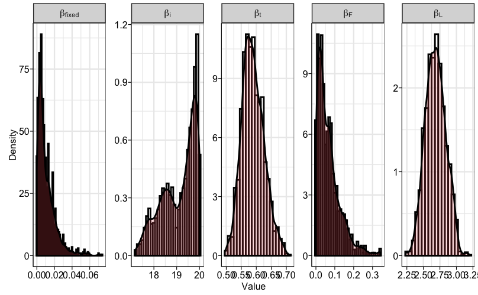

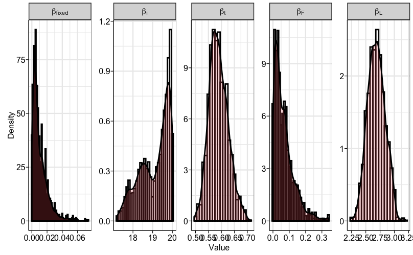

```r
nomParamPosteriors
nomParamPosteriors

# ggsave(file="../writing/pics/exp3-paramposteriors.pdf",width=9,height=2)
ggsave("../writing/pics/fig19.tiff",units="in",width=5.7,height=1.3,dpi=600)
```

## Predictives

Load empirical data and get into right format.

```r
emp = read.csv("../models/bdaInput/nominal/bda_data.csv")
```

Load predictives and get into right format.

Bind empirical and predictives and create scatterplot.

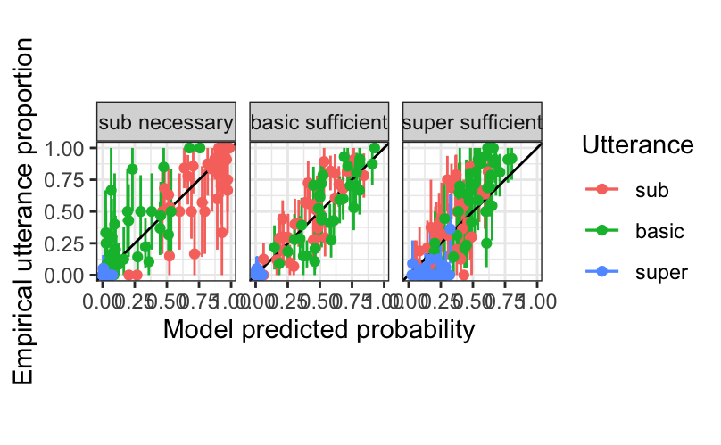

```r
ggsave("../writing/pics/fig16.eps",units="in",width=5.3,height=3.2)#,device=cairo_ps,fallback_resolution = 600)#,dpi=600)
```

## Model comparison

Load BF results

```r
AIS.samples <- read_csv('../models/BFOutput/BF_nominal.txt', col_names = c('modelVersion', 'costs', 'semantics', 'margLikelihood')) %>%
  group_by(modelVersion, costs, semantics) %>%
  summarize(m = mean(margLikelihood))

# no cost vs. cost
AIS.samples %>%
  spread(costs, m) %>%
  mutate(noneVsEmpBF = exp(empirical - none)) %>%
  select(noneVsEmpBF)
```

[output not shown]